```python
# import librairies

import numpy as np # linear algebra
import pandas as pd # data processing, CSV file I/O (e.g. pd.read_csv)
import json

# Visualization
import matplotlib.pyplot as plt
from wordcloud import WordCloud
from PIL import Image
import seaborn as sns
import matplotlib.pyplot as plt
%matplotlib inline

from sklearn import feature_extraction, linear_model, model_selection, preprocessing

# Vectorizer
from sklearn.feature_extraction.text import TfidfVectorizer, CountVectorizer

# NLP
import nltk
from nltk.stem import WordNetLemmatizer
from nltk.tokenize import wordpunct_tokenize
from nltk.corpus import words, stopwords, wordnet
from nltk.tokenize import RegexpTokenizer

from collections import Counter

# Import regex and time
import re
import time

# Gensim
import gensim
import gensim.corpora as corpora
from gensim.corpora import Dictionary
from gensim.models import CoherenceModel, LdaModel
from gensim.models import Phrases

import emoji

# Plotting tools
import pyLDAvis
import pyLDAvis.gensim_models  # don't skip this

# Disable deprecation warnings
import warnings
warnings.filterwarnings("ignore",category=DeprecationWarning)

#nltk.download('all')
```

# NLP: modeling topics of dissatisfaction in Yelp restaurant reviews

```python
df = pd.read_csv("bad_reviews.csv")
```

```python
print(f"The dataframe is composed of {df.shape[0]} rows and {df.shape[1]} columns.")
df.head(5)
```

```
The dataframe is composed of 32535 rows and 2 columns.
```

|  | stars | text |
| --- | --- | --- |
| 0 | 1 | I went here when if first opened, and have nev... |
| 1 | 2 | Ordered Caramel frappe at Drive thru, BIG MIST... |
| 2 | 1 | Food was great. But very disappointed with the... |
| 3 | 1 | Ordered an iced mocha and an iced white choco... |
| 4 | 1 | I'm a Barbecue judge and this ain't barbecue. ... |

```python
# Take sample of dataset

data = df.sample(n=10000, replace=False)
data = data.reset_index().drop(columns=["index", "stars"])

data.text.head(20)
```

[output not shown]

## Preprocessing the reviews

```python
def display_tokens_info(tokens):
    print(f"nb tokens {len(tokens)}, nb tokens uniques {len(set(tokens))}")
    print(tokens[:30])
```

We use the WordNet lemmatizer from NLTK which produces more readable words, allowing us to easier comprehend the results. The steps taken to preprocess each review are:

1. Demojize the emojis: transform emojis to words
2. Transform review to all lowercase
3. Split each review into a list of separate words or tokens
4. Remove all english language stop words plus the word "food"
5. Lemmatize each review
6. Keep only words longer than 3 characters
7. Keep only nouns
8. Return the list of filtered words

```python
stop_words = set(stopwords.words('english'))
stop_words.add('food')
lem = WordNetLemmatizer()
tokenizer = nltk.RegexpTokenizer(r'[a-zA-Z]+')

def text_cleaner(text):

    text = emoji.demojize(text, delimiters=("", "")) # demojize the emojis in the docs

    text = text.lower() # to lowercase

    text = tokenizer.tokenize(text) # tokenize with regular expressions

    text = [w for w in text if w not in stop_words] # remove stopwords

    text = [lem.lemmatize(w) for w in text] # lemmatize with WordNetLemmatizer

    text = [w for w in text if len(w) > 3] # keep only words longer than 3 characters

    ### keep only nouns

    pos_tag = nltk.pos_tag(text)
    noun_text = []

    for i in range (0, (len(text)-1)):

        if (pos_tag[i][1] == 'NN'):
            noun_text.append(pos_tag[i][0])

    text = noun_text

    ###

    return text
```

```python
data["clean_text"] = data["text"].apply(lambda row : text_cleaner(row))
```

Our dataframe now looks like the following, with a separate column for the cleaned text:

```python
data
```

|  | text | clean_text |
| --- | --- | --- |
| 0 | From my experience, I won't go back. Waitress ... | [experience, menu, quality, management, concer... |
| 1 | Big shakes... more like Big Mistake! I am all ... | [shake, chance, visit, time, location, right, ... |
| 2 | I'm visiting the area and asked @ the front de... | [area, hotel, pizza, desk, kick, order, delive... |
| 3 | This place.... Wow! I've given it enough tries... | [place, today, sushi, cold] |
| 4 | I don't normally write reviews for fast food r... | [review, anything, anyway, vacation, today, th... |
| ... | ... | ... |
| 9995 | Not that great, and sushi is definitely not th... | [sushi, quality, location, convenient, roll] |
| 9996 | We ate here about a year ago and the food was ... | [year, friend, quality, chip, salsa, metal, wi... |
| 9997 | Been here numerous times before and enjoyed it... | [time, john, besh, visit, visit, gumbo, nothin... |
| 9998 | I went there for Sunday brunch and was unimpre... | [brunch, water, benedict] |
| 9999 | The food is good I've gotten chicken wings to ... | [chicken, broccoli, rice, service, chicken, so... |

10000 rows × 2 columns

## Before and after text preprocessing

```python
corpus_original = wordpunct_tokenize(" ".join(data.text.values))
corpus_clean = np.concatenate(data.clean_text)
```

```python
print(f"Unique tokens before cleaning: {len(set(corpus_original))}")
print(f"Unique tokens after cleaning: {len(set(corpus_clean))}")
```

```
Unique tokens before cleaning: 28767
Unique tokens after cleaning: 9708
```

### Corpus before cleaning

```python
display_tokens_info(corpus_original)
```

```
nb tokens 1397619, nb tokens uniques 28767
['From', 'my', 'experience', ',', 'I', 'won', "'", 't', 'go', 'back', '.', 'Waitress', 'was', 'not', 'interested', 'in', 'her', 'job', ',', 'not', 'knowledgeable', 'of', 'the', 'menu', '...', 'Food', 'quality', 'was', 'sub', 'par']
```

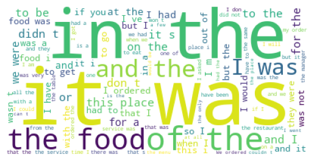

```python
wordcloud = WordCloud(background_color='white',
                        stopwords=[],
                        max_words=100).generate(" ".join(corpus_original))
plt.imshow(wordcloud)
plt.axis("off")
plt.show()
```

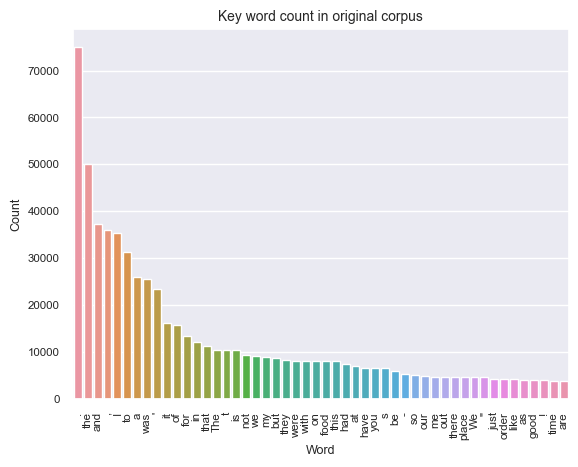

```python
# Bar plot - Create a dataframe of the most common 30 words
common_words = pd.DataFrame(Counter(corpus_original).most_common(50))
common_words.columns = ('Word', 'Count')# Plot a bar chart of the most common 20 words
sns.set(font_scale = 0.75)
sns.barplot(x= common_words['Word'], y=common_words['Count'])
plt.xticks(rotation='vertical')
plt.title("Key word count in original corpus", fontsize = 10)
plt.show()
```

### Corpus after cleaning

```python
display_tokens_info(corpus_clean)
```

```
nb tokens 196840, nb tokens uniques 9708
['experience' 'menu' 'quality' 'management' 'concern' 'money' 'shake'
 'chance' 'visit' 'time' 'location' 'right' 'order' 'employee' 'hold'
 'employee' 'music' 'artist' 'deal' 'kind' 'visit' 'location' 'mood'
 'ruin' 'love' 'chicken' 'till' 'tender' 'meal' 'rambo']
```

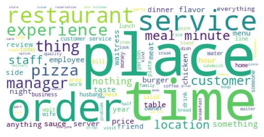

```python
wordcloud = WordCloud(background_color='white',
                        max_words=100).generate(" ".join(corpus_clean))
plt.imshow(wordcloud)
plt.axis("off")
plt.show()
```

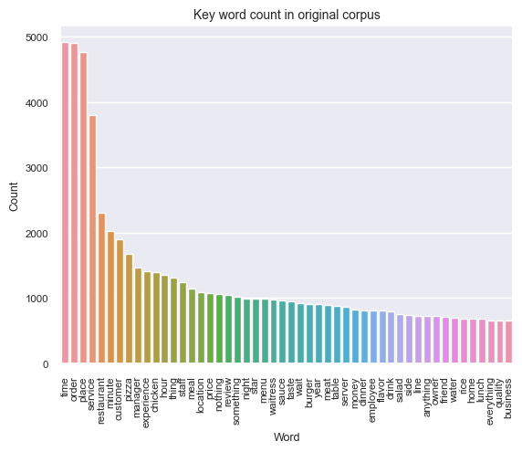

```python
# Bar plot - Create a dataframe of the most common 30 words
common_words = pd.DataFrame(Counter(corpus_clean).most_common(50))
common_words.columns = ('Word', 'Count')# Plot a bar chart of the most common 20 words
sns.set(font_scale = 0.75)
sns.barplot(x= common_words['Word'], y=common_words['Count'])
plt.xticks(rotation='vertical')
plt.title("Key word count in original corpus", fontsize = 10)
plt.show()
```

## Train LDA model

The LDA or the Latent Dirichlet Allocation model will allow us to detect topics in our reviews, sets of words that cluster together and have a higher probability to appear together in a review.

At first we will use a smaller sample of 1000 of the reviews in order to calculate the ideal number of topics, after which we will give our final model 5000 reviews to have the most precision in our topics.

```python
data_sample = data.sample(n=1000, replace=False)
data_sample = data_sample.reset_index()
data_sample.drop(columns=['index'], inplace=True)
```

```python
# Create Dictionary
id2word = corpora.Dictionary(data_sample.clean_text)

# Term Document Frequency
corpus = [id2word.doc2bow(text) for text in data_sample.clean_text]

topics = []
coherence = []

for t in range(3, 7):

    lda = LdaModel( corpus=corpus,
                    id2word=id2word,
                    num_topics=t,
                    alpha=50/t,
                    eta=0.1,
                    per_word_topics=True)

    coherence_model_lda = CoherenceModel(model=lda, texts=data_sample.clean_text, dictionary=id2word, coherence='c_v')
    # coherence_model_lda = CoherenceModel(model=lda, corpus=corpus, dictionary=id2word, coherence='u_mass')
    coherence_lda = coherence_model_lda.get_coherence()

    topics.append(t)
    coherence.append(coherence_lda)

results = pd.DataFrame(columns=["Topics", "Coherence"])
results["Topics"] = topics
results["Coherence"] = coherence
```

In order to calculate the ideal number of topics, we check the coherence score of our model. We have the option of using u_mass coherence, which is faster computationally but less accurate or to use c_v, which is slower but more accurate. I decided to use a sample of 1000 reviews and calculate the c_v, which explains the apparently lower than expected score. If we were to take a larger sample size or use the whole dataset of reviews, our c_v score would be much higher.

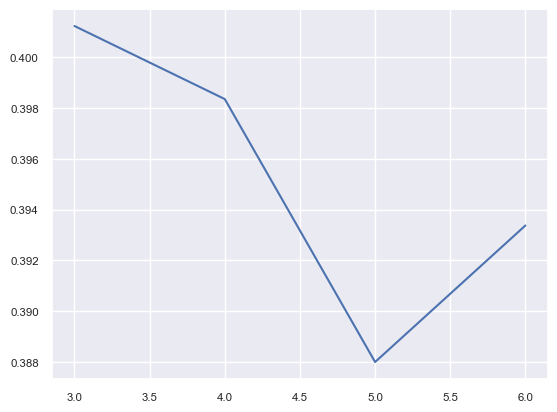

```python
sns.lineplot(results, x=topics, y=coherence)
```

## Topics observed by the LDA model:

```python
data_sample = data.sample(n=5000, replace=False)
data_sample = data_sample.reset_index()
data_sample.drop(columns=['index'], inplace=True)
```

```python
# Create Dictionary
id2word = corpora.Dictionary(data_sample.clean_text)

# Term Document Frequency
corpus = [id2word.doc2bow(text) for text in data_sample.clean_text]

lda = LdaModel( corpus=corpus,
                    id2word=id2word,
                    num_topics=4,
                    chunksize=100,
                    minimum_probability=0.01,
                    passes=100,
                    alpha=50/4,
                    eta=0.1,
                    per_word_topics=True)
lda.print_topics()
```

```
[(0,
  '0.096*"place" + 0.046*"restaurant" + 0.023*"nothing" + 0.023*"review" + 0.020*"something" + 0.020*"year" + 0.016*"owner" + 0.014*"water" + 0.014*"anything" + 0.012*"business"'),
 (1,
  '0.029*"chicken" + 0.024*"meal" + 0.021*"sauce" + 0.021*"taste" + 0.019*"thing" + 0.018*"menu" + 0.018*"meat" + 0.018*"flavor" + 0.016*"salad" + 0.015*"side"'),
 (2,
  '0.098*"time" + 0.082*"service" + 0.038*"minute" + 0.037*"customer" + 0.031*"hour" + 0.028*"manager" + 0.027*"experience" + 0.022*"night" + 0.022*"staff" + 0.020*"waitress"'),
 (3,
  '0.115*"order" + 0.041*"pizza" + 0.024*"location" + 0.023*"price" + 0.023*"star" + 0.022*"money" + 0.021*"burger" + 0.015*"home" + 0.014*"person" + 0.014*"phone"')]
```

### pyLDAvis visualization of the intertopic distance and top-30 most relevant terms per topic

```python
pyLDAvis.enable_notebook()
pyLDAvis.gensim_models.prepare(lda, corpus, id2word)
```

[interactive chart not shown]

### WordClouds per topic

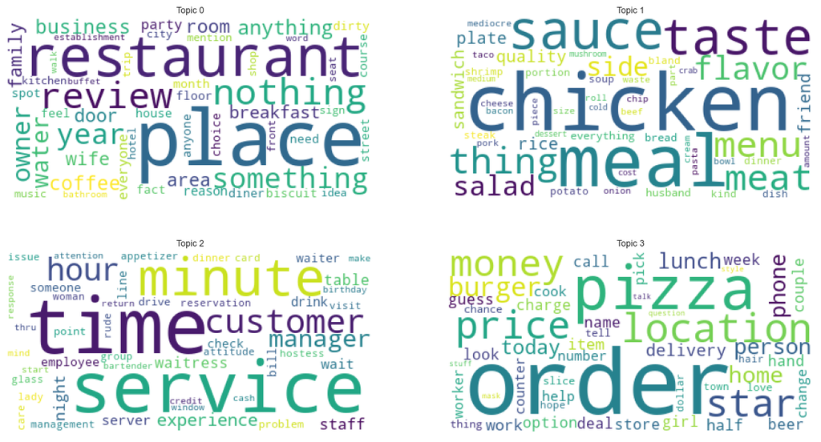

```python
nbr_rows = int(lda.num_topics/2) if lda.num_topics % 2 == 0 else int((lda.num_topics+1)/2)
index = 1

fig, axs = plt.subplots(nbr_rows, 2, figsize=(15,4*nbr_rows))

for t in range(lda.num_topics):
    plt.subplot(nbr_rows, 2, index)
    plt.imshow(WordCloud(background_color = 'white').fit_words(dict(lda.show_topic(t, 50))))
    plt.axis("off")
    plt.title("Topic " + str(t))

    index+=1

plt.show()
```

## Conclusion

We can see four clear topics emerge:

1. Insatisfaction about the restaurant, the place itself.
2. Insatisfaction about the food, the taste, the flavor, the meal.
3. Insatisfaction about the service, many time words such as hour and minute indicate that maybe the service was too slow. The experience, the management, the staff.
4. Problems with the order, the location, the price/money.